# A3

Antonio Roldán Andrade

2025-12-15

## 1 Regresión Lineal

### 1.1 Carga y preparación de los datos

```r
csv_location <- "salarios_INE_2022_sample.csv"
salariosDataSet <- read.csv(csv_location, sep = ",")

head(salariosDataSet,5)
```

```
##   IDENCCC ORDENTRA NUTS1 CNACE ESTRATO2 CONTROL MERCADO REGULACION SEXO
## 1   21318        3     2    F0        1       1       2          2    1
## 2   16532        5     2    F0        2       2       2          2    1
## 3   22925        8     3    G2        3       2       4          2    1
## 4    4922       12     3    G2        3       2       2          1    6
## 5   11276        9     2    C8        2       2       2          2    6
##   TIPOPAIS CNO1 RESPONSA ESTU ANOANTI MESANTI TIPOJOR TIPOCON FIJODISM FIJODISD
## 1        1   L0        0    4      12       8       1       2        0        0
## 2        1   L0        0    5      14      10       1       1        0        0
## 3        1   D0        0    5      14       4       1       1        0        0
## 4        1   G0        0    5       3       2       2       1        0        0
## 5        2   M0        0    2       3       3       1       1        0        0
##   VAL VAN PUENTES  JAP JSP1 JSP2 HEXTRA DRELABM SIESPM1 DSIESPM1 SIESPM2
## 1   0  30       0 1736   40    0      0      31       6        0       6
## 2   0  30       0 1760   40    0      0      31       6        0       6
```

[output cut: 21 more lines]

```r
salariosDataSet <- salariosDataSet %>%
 mutate(
  # 1. CONVERSIÓN Y ETIQUETADO DE VARIABLES CATEGÓRICAS SIMPLES

  TIPOPAIS = factor(TIPOPAIS,
                             levels = c(1, 2),
                             labels = c("España", "Otra")),

  SEXO = factor(SEXO,
         levels = c(1, 6), # 1=Hombre, 6=Mujer
         labels = c("Hombre", "Mujer")),

  # ESTU (Nivel de Estudios): Sobrescribe la columna 'ESTU'
  ESTU = factor(ESTU,
         levels = c(1, 2, 3, 4, 5, 6),
         labels = c("1. Sin Estudios/Primaria Incompleta",
              "2. Primaria Completa",
              "3. Secundaria 1ª Etapa (E.S.O.)",
              "4. Secundaria 2ª Etapa (Bachillerato)",
              "5. Formación Profesional",
              "6. Estudios Superiores")),

  # ANOS2 (Grupos de Edad): Sobrescribe la columna 'ANOS2'
  ANOS2 = factor(ANOS2,
         levels = c(1, 2, 3, 4, 5, 6),
         labels = c("1. Menos de 19",
               "2. 20 a 29",
               "3. 30 a 39",
               "4. 40 a 49",
               "5. 50 a 59",
               "6. 60 y más"
              )),


  # 2. RECODIFICACIÓN ESPECÍFICA DE CNACE (Actividad Económica)

  CNACE = case_when(
  # Extraemos el primer carácter y comparamos
    substr(CNACE, 1, 1) %in% c("B", "C", "D", "E", "F") ~ "1. Industria y Construcción",

    # Nivel 2: O, P, Q
    substr(CNACE, 1, 1) %in% c("O", "P", "Q") ~ "2. Servicios Públicos Clave",

    # Nivel 3: El resto (como G1, H2, J0, M0, etc.)
    TRUE ~ "3. Otros Servicios y Actividades"
  ),

  # Creamos la nueva variable
  CNACE_grp = factor(CNACE,
         levels = c("1. Industria y Construcción",
               "2. Servicios Públicos Clave",
               "3. Otros Servicios y Actividades")),


  # 3. RECODIFICACIÓN ESPECÍFICA DE CNO1

  CNO1 = case_when(
   # Nivel 1: A0–C0 (Directores y Técnicos/Profesionales)
   substr(CNO1, 1, 1) %in% c("A", "B", "C") ~ "1. Dirección y Alta Cualificación",
   # Nivel 2: D0–J0 (Técnicos de Apoyo, Empleados, Servicios, Agricultores)
   substr(CNO1, 1, 1) %in% c("D", "E", "F", "G", "H", "I", "J") ~ "2. Cualificación Media",
   # Nivel 3: El resto (K0, L0, M0, N0, O0, P0, Q0)
   TRUE ~ "3. Baja Cualificación y Elementales"
  ),

  # Convertir CNO1 a factor y ordenar los niveles
  CNO1_grp = factor(CNO1,
         levels = c("1. Dirección y Alta Cualificación",
              "2. Cualificación Media",
              "3. Baja Cualificación y Elementales"))
 )
```

## 1.2 Estudio de correlación lineal

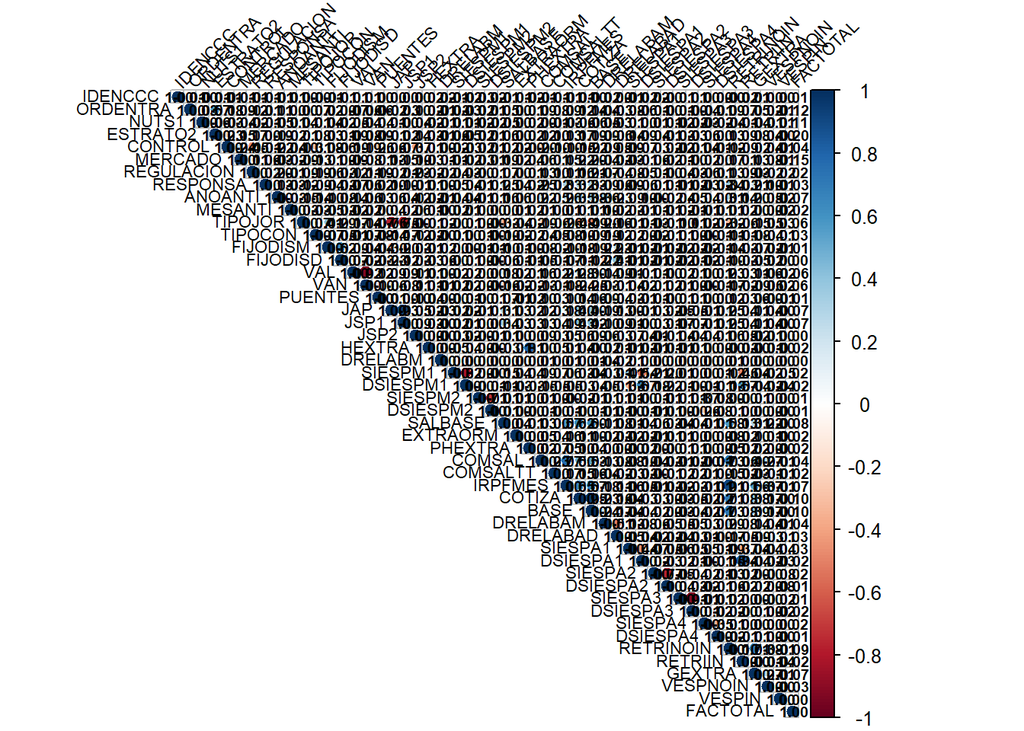

```r
# Extraemos todas las variables cuantitativas de la tabla
datos_cuantitativos <- salariosDataSet %>%
  select(where(is.numeric))

# Una vez tenemos los datos procedemos a realizar la matriz de correlacion
matriz_correlacion <- cor(datos_cuantitativos, use = "pairwise.complete.obs")
# 3. Visualizar la matriz
corrplot(matriz_correlacion,
         method = "circle", # Puedes usar "square" o "number"
         type = "upper",    # Muestra solo la mitad superior
         tl.cex = 0.7,      # Tamaño de la fuente de las etiquetas
         tl.col = "black",  # Color de las etiquetas
         tl.srt = 45,       # Rotación de las etiquetas
         addCoef.col = "black", # Añade el número del coeficiente (opcional)
         number.cex = 0.6)      # Tamaño de los números (si los añades)
```

Como podemos apreciar la matriz es enorme, por lo que realizaremos un filtrado por elementos con una correlación alta (>= 0.7), con esto tendremos una mayor facilidad para obtener un resultado estudiable

```r
correlaciones_df <- as.data.frame(matriz_correlacion) %>%
  tibble::rownames_to_column("Var1") %>%
  # Nos vamos moviendo para tener una fila por cada par de correlación
  tidyr::pivot_longer(cols = -Var1, names_to = "Var2", values_to = "Correlacion") %>%

  # Aseguramos que no comparemos Var1 vs Var2 y Var2 vs Var1, y que no sea la diagonal (Var1 == Var2)
  filter(Var1 < Var2) %>%

  # Buscar correlaciones fuertes (|r| > 0.7)
  filter(abs(Correlacion) > 0.7) %>%

  # Ordenar por el valor absoluto de la correlación (de más fuerte a más débil)
  arrange(desc(abs(Correlacion)))

# Imprimir las correlaciones más fuertes
print("Pares de variables con correlación |r| > 0.7:")
```

```
## [1] "Pares de variables con correlación |r| > 0.7:"
```

```r
print(correlaciones_df)
```

```
## # A tibble: 17 × 3
##    Var1     Var2      Correlacion
##    <chr>    <chr>           <dbl>
##  1 BASE     COTIZA          0.953
##  2 JAP      JSP1            0.927
##  3 VAL      VAN            -0.924
##  4 IRPFMES  RETRINOIN       0.914
##  5 DSIESPA3 SIESPA3        -0.913
##  6 DSIESPA1 RETRIIN         0.835
##  7 DSIESPM1 SIESPM1        -0.823
##  8 HEXTRA   PHEXTRA         0.807
##  9 DSIESPA2 SIESPA2        -0.769
## 10 COMSAL   IRPFMES         0.766
## 11 JAP      TIPOJOR        -0.761
## 12 JSP1     TIPOJOR        -0.751
## 13 BASE     RETRINOIN       0.728
## 14 COMSAL   RETRINOIN       0.726
## 15 DSIESPM2 SIESPM2        -0.712
## 16 GEXTRA   RETRINOIN       0.712
## 17 COTIZA   RETRINOIN       0.710
```

Podemos apreciar la existencia de múltiples variables con una fuerte correlación pudiendo destacar:

- BASE <-> COTIZA: Como es lógico existe una fuerte correlación entre las contribuciones a la seguridad social y la base de cotización a la seguridad social, existe una correlación positiva entre ambas casi completa (0.953).
- JAP <-> JSP1: Cuanto mayor es la jornada laboral anual pactada mayor será la jornada semanal en la mayoría de los casos.
- IRPF <-> RETRINOIN: Consecuentemente, cuanto mayor es el salario bruto anual mayor será la cantidad de IRPF que tendrá que pagar el trabajador.

### 1.4. Generación de los conjuntos de entrenamiento y de test

```r
# Fijar la semilla para reproducibilidad
set.seed(42)

#`1. Crear el vector de índices para la muestra de entrenamiento (80%) ---

tamano_train <- floor(0.80 * nrow(salariosDataSet))

# seleccionamos los índices de las filas que irán a 'train'
indices_train <- sample(seq_len(nrow(salariosDataSet)), size = tamano_train)

# --- 2. Separar los conjuntos de datos ---

train <- salariosDataSet[indices_train, ]

test <- salariosDataSet[-indices_train, ]

print(paste("Tamaño total:", nrow(salariosDataSet)))
```

```
## [1] "Tamaño total: 10000"
```

```r
print(paste("Tamaño train (80%):", nrow(train)))
```

```
## [1] "Tamaño train (80%): 8000"
```

```r
print(paste("Tamaño test (20%):", nrow(test)))
```

```
## [1] "Tamaño test (20%): 2000"
```

### 1.5. Estimación de modelos de regresión lineales simples con variable cualitativa

```r
# M1: RETRINOIN en función de SEXO
# Usamos Lm ya que estamos en un estudio de regresión lineal simple
modelo_sexo <- lm(RETRINOIN ~ SEXO, data = train)

# Mostrar el resumen del modelo 1
summary(modelo_sexo)
```

```
##
## Call:
## lm(formula = RETRINOIN ~ SEXO, data = train)
##
## Residuals:
##    Min     1Q Median     3Q    Max
## -31054 -12995  -5421   6708 505074
##
## Coefficients:
##             Estimate Std. Error t value Pr(>|t|)
## (Intercept)  31053.9      364.2   85.27   <2e-16 ***
## SEXOMujer    -6472.0      543.4  -11.91   <2e-16 ***
## ---
## Signif. codes:  0 '***' 0.001 '**' 0.01 '*' 0.05 '.' 0.1 ' ' 1
##
## Residual standard error: 24170 on 7998 degrees of freedom
## Multiple R-squared:  0.01743,    Adjusted R-squared:  0.01731
## F-statistic: 141.9 on 1 and 7998 DF,  p-value: < 2.2e-16
```

**Con respecto a la si estas estadísticas son significativas tenemos:**

Puesto que el p-valor del coeficiente es <2e-16, esto implica que dado que es un valor extremadamente pequeño y es mucho menor que el umbral de significación (alpha = 0.05) por tanto podemos rechazar la hipotesis nula (Ho: coeficiente es 0).

Por tanto podemos decir que la diferencia salarial media estimada de $-6472.0$ es estadísticamente significativa.

**Si nos centramos en la interpretación de $R^2$ tenemos:** El valor obtenido R-Squared es del 1.731 %, por lo que podemos decir la variable SEXO influye únicamente en el $1.73%$ de la variabilidad de la varianza pudiendo asumir que aún siendo la diferencia salarial es estadísticamente significativa, el modelo es débil desde el punto de vista predictivo. La mayor parte de la variación salarial ($\approx 98.27\%$) se debe a otros factores no incluidos en este modelo simple.

```r
modelo_pais <- lm(RETRINOIN ~ TIPOPAIS, data = train)

# Mostrar el resumen del modelo 1
summary(modelo_pais)
```

```
##
## Call:
## lm(formula = RETRINOIN ~ TIPOPAIS, data = train)
##
## Residuals:
##    Min     1Q Median     3Q    Max
## -28533 -13227  -5209   6605 507595
##
## Coefficients:
##              Estimate Std. Error t value Pr(>|t|)
## (Intercept)   28532.6      282.2 101.103  < 2e-16 ***
## TIPOPAISOtra  -5547.2     1069.5  -5.187  2.2e-07 ***
## ---
## Signif. codes:  0 '***' 0.001 '**' 0.01 '*' 0.05 '.' 0.1 ' ' 1
##
## Residual standard error: 24350 on 7998 degrees of freedom
## Multiple R-squared:  0.003352,   Adjusted R-squared:  0.003227
## F-statistic:  26.9 on 1 and 7998 DF,  p-value: 2.195e-07
```

Puesto que el $p$-valor del coeficiente es $2.2\text{e-}07$, esto implica que dado que es un valor extremadamente pequeño y es mucho menor que el umbral de significación ($\alpha = 0.05$), por lo tanto podemos rechazar la hipótesis nula ($H_0$: el coeficiente es 0).  
Por lo tanto, podemos decir que la diferencia salarial media estimada de $-5547$ es estadísticamente significativa.

**Si nos centramos en la interpretación de $R^2$ tenemos:**  
El valor obtenido $R^2$ Ajustado es del $0.3227\%$ ($0.003227$), por lo que podemos decir la variable $TIPOPAIS$ influye únicamente en el $0.3227\%$ de la variabilidad de la varianza de la retribución, pudiendo asumir que aun siendo la diferencia salarial estadísticamente significativa, el modelo es extremadamente débil desde el punto de vista predictivo.  
La mayor parte de la variación salarial ($\approx 99.68\%$) se debe a otros factores no incluidos en este modelo simple.

### 1.6 Estimación del modelo de regresión lineal múltiple con predictores cuantitativos

Haremos ahora las regresiones lineales para la variables RETROIN, ANOANTI y JAP:

```r
modelo_antiguedad_jornada <- lm(RETRINOIN ~ ANOANTI + JAP, data = train)

summary(modelo_antiguedad_jornada)
```

```
##
## Call:
## lm(formula = RETRINOIN ~ ANOANTI + JAP, data = train)
##
## Residuals:
##    Min     1Q Median     3Q    Max
## -49203 -11024  -4369   4762 503785
##
## Coefficients:
##               Estimate Std. Error t value Pr(>|t|)
## (Intercept) -5862.9176  1232.9114  -4.755 2.02e-06 ***
## ANOANTI       712.8970    24.8321  28.709  < 2e-16 ***
## JAP            16.3664     0.7437  22.006  < 2e-16 ***
## ---
## Signif. codes:  0 '***' 0.001 '**' 0.01 '*' 0.05 '.' 0.1 ' ' 1
##
## Residual standard error: 22500 on 7997 degrees of freedom
## Multiple R-squared:  0.1492, Adjusted R-squared:  0.149
## F-statistic: 701.1 on 2 and 7997 DF,  p-value: < 2.2e-16
```

Del resultado mostrado en la regresión lineal podemos inferir:

1. La variable independiente representa la retribución de un trabajador con 0 experiencia y 0 horas de jornada laboral anual, esto nos ayuda para los cálculos posteriores.
2. La variable ANOANTI nos indica que por cada año que pasa la retribución aumenta $712.9$ euros.
3. Por cada hora adicional pactada anualmente la retribución aumenta $16,36$ euros.

**Interpretación de $R^2$ Ajustado**

1. El $R^2$ Ajustado del $14.9\%$ es sustancialmente mayor que los modelos simples anteriores (M1 con $\approx 1.73\%$ y M2 con $\approx 0.32\%$).
2. Confirmando que las variables cuantitativas de “cantidad de trabajo y experiencia” son, efectivamente, mejores predictores de la retribución que las variables categóricas de sexo o nacionalidad.
3. El modelo sigue siendo moderadamente débil, ya que el $85.1\%$ restante de la variabilidad en el salario se explica por otros factores.

## 1.7 Estimación del modelo de regresión lineal múltiple con predictores cuantitativos y cualitativos

Para dar respuesta a este ejercicio ajustamos el modelo de la siguiente manera:
$$\text{RETRINOIN} \sim \text{ANOANTI} +
\text{JAP} + \text{SEXO} + \text{TIPOPAIS} + \text{ESTU} + \text{ANOS2}
+ \text{CNO1_grp}$$

```r
modelo_completo <- lm(RETRINOIN ~ ANOANTI + JAP + SEXO + TIPOPAIS + ESTU +
                                  ANOS2 + CNO1_grp,
                                  data = train)

# Mostrar el resumen del modelo y calcular VIF
print("--- Resumen del Modelo Completo (M4_final) ---")
```

```
## [1] "--- Resumen del Modelo Completo (M4_final) ---"
```

```r
summary(modelo_completo)
```

```
##
## Call:
## lm(formula = RETRINOIN ~ ANOANTI + JAP + SEXO + TIPOPAIS + ESTU +
##     ANOS2 + CNO1_grp, data = train)
##
## Residuals:
##    Min     1Q Median     3Q    Max
## -56813  -7153  -1380   4685 300684
##
## Coefficients:
##                                               Estimate Std. Error t value
## (Intercept)                                  2.993e+03  3.571e+03   0.838
## ANOANTI                                      5.137e+02  2.117e+01  24.261
## JAP                                          1.129e+01  5.341e-01  21.134
## SEXOMujer                                   -6.884e+03  3.822e+02 -18.009
## TIPOPAISOtra                                 1.552e+03  6.972e+02   2.226
## ESTU2. Primaria Completa                     1.479e+03  2.239e+03   0.661
## ESTU3. Secundaria 1ª Etapa (E.S.O.)          2.168e+03  2.223e+03   0.975
## ESTU4. Secundaria 2ª Etapa (Bachillerato)    5.620e+03  2.234e+03   2.515
## ESTU5. Formación Profesional                 8.889e+03  2.270e+03   3.916
## ESTU6. Estudios Superiores                   1.312e+04  2.293e+03   5.723
## ANOS22. 20 a 29                             -2.012e+03  2.775e+03  -0.725
## ANOS23. 30 a 39                              1.453e+03  2.758e+03   0.527
## ANOS24. 40 a 49                              3.533e+03  2.752e+03   1.284
## ANOS25. 50 a 59                              4.060e+03  2.763e+03   1.469
## ANOS26. 60 y más                             1.947e+03  2.808e+03   0.693
## CNO1_grp2. Cualificación Media              -7.536e+03  7.065e+02 -10.666
## CNO1_grp3. Baja Cualificación y Elementales -1.007e+04  7.911e+02 -12.728
##                                             Pr(>|t|)
## (Intercept)                                   0.4021
## ANOANTI                                      < 2e-16 ***
## JAP                                          < 2e-16 ***
## SEXOMujer                                    < 2e-16 ***
## TIPOPAISOtra                                  0.0260 *
## ESTU2. Primaria Completa                      0.5089
## ESTU3. Secundaria 1ª Etapa (E.S.O.)           0.3295
## ESTU4. Secundaria 2ª Etapa (Bachillerato)     0.0119 *
## ESTU5. Formación Profesional                9.08e-05 ***
## ESTU6. Estudios Superiores                  1.09e-08 ***
## ANOS22. 20 a 29                               0.4685
## ANOS23. 30 a 39                               0.5983
## ANOS24. 40 a 49                               0.1991
## ANOS25. 50 a 59                               0.1418
## ANOS26. 60 y más                              0.4881
## CNO1_grp2. Cualificación Media               < 2e-16 ***
## CNO1_grp3. Baja Cualificación y Elementales  < 2e-16 ***
## ---
## Signif. codes:  0 '***' 0.001 '**' 0.01 '*' 0.05 '.' 0.1 ' ' 1
##
## Residual standard error: 14550 on 6656 degrees of freedom
##   (1327 observations deleted due to missingness)
## Multiple R-squared:  0.3521, Adjusted R-squared:  0.3506
## F-statistic: 226.1 on 16 and 6656 DF,  p-value: < 2.2e-16
```

```r
vif(modelo_completo)
```

```
##              GVIF Df GVIF^(1/(2*Df))
## ANOANTI  1.473097  1        1.213712
## JAP      1.089772  1        1.043921
## SEXO     1.132325  1        1.064108
## TIPOPAIS 1.058243  1        1.028709
## ESTU     2.256403  5        1.084780
## ANOS2    1.531004  5        1.043512
## CNO1_grp 2.300600  2        1.231573
```

De tal manera el modelo final será:
$$\text{RETRINOIN} \sim \text{ANOANTI} +
\text{JAP} + \text{SEXO} + \text{TIPOPAIS} + \text{ESTU} +
\text{CNO1_grp}$$

```r
modelo_completov2 <- lm(RETRINOIN ~ ANOANTI + JAP + SEXO + TIPOPAIS + ESTU +
                                   CNO1_grp,
                                  data = train)

# Mostrar el resumen del modelo
print("--- Resumen del Modelo Completo (M4_final) ---")
```

```
## [1] "--- Resumen del Modelo Completo (M4_final) ---"
```

```r
summary(modelo_completov2)
```

```
##
## Call:
## lm(formula = RETRINOIN ~ ANOANTI + JAP + SEXO + TIPOPAIS + ESTU +
##     CNO1_grp, data = train)
##
## Residuals:
##    Min     1Q Median     3Q    Max
## -58612  -7173  -1240   4625 301656
##
## Coefficients:
##                                               Estimate Std. Error t value
## (Intercept)                                  4451.1396  2497.4106   1.782
## ANOANTI                                       580.3314    17.9921  32.255
## JAP                                            11.6744     0.5296  22.044
## SEXOMujer                                   -6709.3486   384.1216 -17.467
## TIPOPAISOtra                                 1331.5948   700.4178   1.901
## ESTU2. Primaria Completa                     1355.3587  2253.6687   0.601
## ESTU3. Secundaria 1ª Etapa (E.S.O.)          1833.9614  2236.6717   0.820
## ESTU4. Secundaria 2ª Etapa (Bachillerato)    5104.4752  2247.3605   2.271
## ESTU5. Formación Profesional                 8271.8031  2281.6020   3.625
## ESTU6. Estudios Superiores                  12368.5643  2305.3531   5.365
## CNO1_grp2. Cualificación Media              -7530.4223   711.0603 -10.590
## CNO1_grp3. Baja Cualificación y Elementales -9888.3134   795.7820 -12.426
##                                             Pr(>|t|)
## (Intercept)                                 0.074746 .
## ANOANTI                                      < 2e-16 ***
## JAP                                          < 2e-16 ***
## SEXOMujer                                    < 2e-16 ***
## TIPOPAISOtra                                0.057326 .
## ESTU2. Primaria Completa                    0.547593
## ESTU3. Secundaria 1ª Etapa (E.S.O.)         0.412273
## ESTU4. Secundaria 2ª Etapa (Bachillerato)   0.023159 *
## ESTU5. Formación Profesional                0.000291 ***
## ESTU6. Estudios Superiores                  8.36e-08 ***
## CNO1_grp2. Cualificación Media               < 2e-16 ***
## CNO1_grp3. Baja Cualificación y Elementales  < 2e-16 ***
## ---
## Signif. codes:  0 '***' 0.001 '**' 0.01 '*' 0.05 '.' 0.1 ' ' 1
##
## Residual standard error: 14650 on 6661 degrees of freedom
##   (1327 observations deleted due to missingness)
## Multiple R-squared:  0.343,  Adjusted R-squared:  0.3419
## F-statistic: 316.1 on 11 and 6661 DF,  p-value: < 2.2e-16
```

Si comparamos el modelo final con el inicial podemos ver como el coeficiente de SexoMujer se ve incrementado de $-6472$ a $-6709.35$.  
Esto sucede al no controlar la variable años de antiguedad entre otras posible causas:

1. Evidencia de Alta Discriminación Residual: La brecha de $-6709.35$ es la diferencia salarial media entre hombres y mujeres que poseen exactamente el mismo perfil objetivo (misma antigüedad, jornada, nivel de estudios y cualificación ocupacional).
2. Implicación Inusual: El hecho de que la brecha ajustada sea mayor que la bruta sugiere que, en promedio, las mujeres en la muestra podrían tener características (como la antigüedad o un nivel de estudios superior) que, en un modelo sin el factor “Sexo”, les darían una prima salarial. Sin embargo, esta ventaja es negada por la penalización del factor “Sexo”.

En cambio si nos centramos en la Brecha salarial por Nacionalidad tenemos que se reduce significativamente dicha brecha, pasa de ser una penalización significativa de $-5547$ (los extranjeros ganan menos) a una prima positiva de $+1331.59$.

1. Brecha Explicada por Capital Humano: La gran diferencia negativa en el modelo inicial era una brecha bruta. Esto significa que los trabajadores de nacionalidad “Otra” tenían, en promedio, características que penalizan fuertemente el salario (ej. menor antigüedad reconocida, concentración en ocupaciones de menor remuneración o estudios no convalidados…
2. Al incluir los factores de control ($\text{ANOANTI}$, $\text{ESTU}$, $\text{CNO1\_grp}$), estas características que penalizaban el salario son absorbidas por el modelo. Una vez que se comparan trabajadores de idéntico perfil objetivo (un español vs. un extranjero con la misma antigüedad y ocupación), la nacionalidad “Otra” está asociada a una prima de $1331.59$ euros.

**NOTA:** Es importante resaltar que esta prima de $+1331.59$ es solo marginalmente no significativa a $\alpha=0.05$ (ya que $p = 0.0573$). Esto sugiere que, mientras que el factor de nacionalidad ya no es una desventaja salarial ajustada, la ventaja es demasiado débil para afirmarla con alta confianza estadística.

### 1.8 Diagnosis del modelo

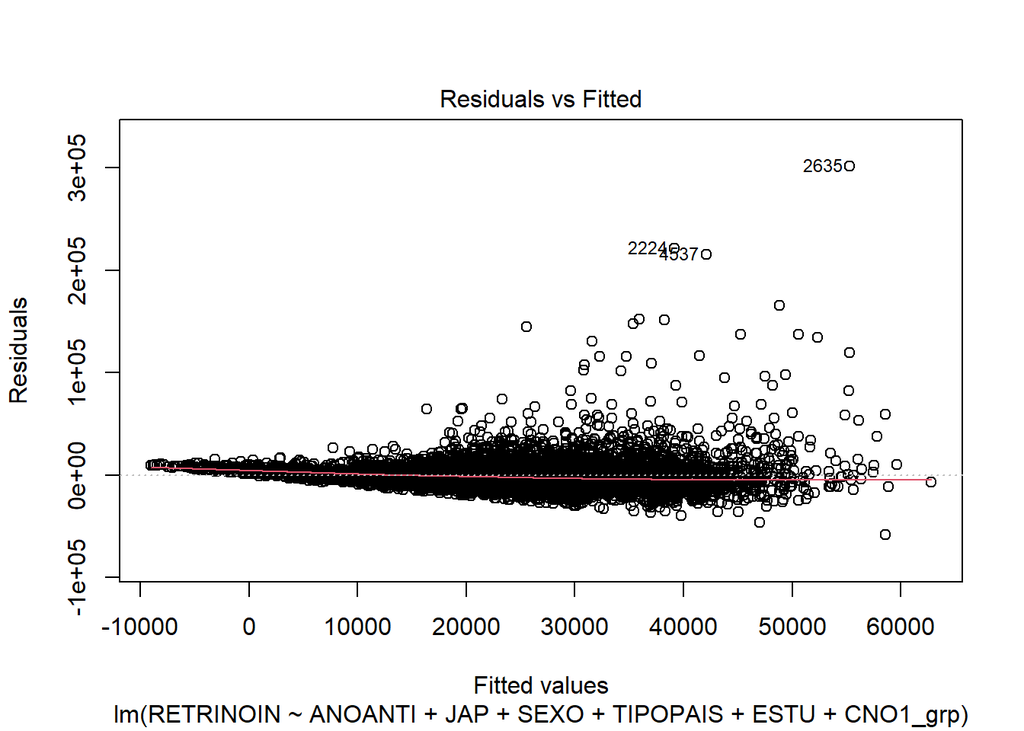

```r
# 1. Gráfico de Residuos vs. Valores Ajustados
plot(modelo_completov2, which = 1)
```

En el primer gráfico (Residual vs Fitted) estudiaremos la homocedasticidad de los datos, pudiendo sacar las siguientes conclusiones:

1. Se observa un claro patrón de “embudo” o “abanico”. Conforme aumentan los valores ajustados (el salario predicho), la dispersión de los residuos se hace mayor, especialmente por la presencia de valores muy altos en la parte superior derecha.
2. Existe heterocedasticidad, debido a que la varianza de los errores no es constante, lo que indica que el modelo es mucho más preciso para predecir salarios bajos y medios que para capturar la variabilidad de los salarios más altos.

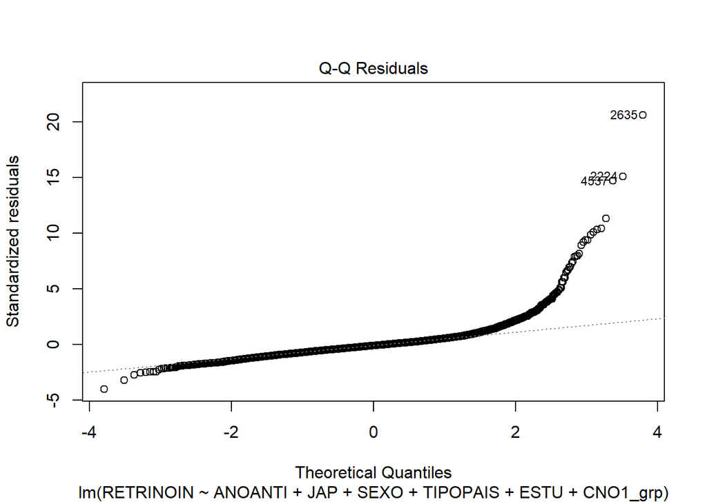

```r
# 2. Gráfico Q-Q de Normalidad
plot(modelo_completov2, which = 2)
```

### 1.9 Predicción del modelo

Usaremos el modelo final para la realización de este apartado ya que es el más completo.

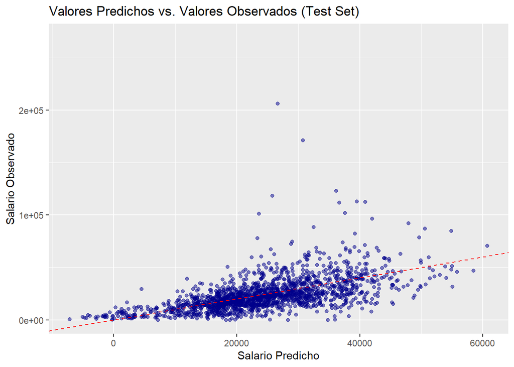

```r
# 1. Realizar predicciones sobre el conjunto test
predicciones <- predict(modelo_completov2, newdata = test)

# Damos X= 0 y pendiente de 1 (Valor predicho será igual al observado)
ggplot(data = test, aes(x = predicciones, y = RETRINOIN)) +
  geom_point(alpha = 0.5, color = "darkblue") +
  geom_abline(intercept = 0, slope = 1, color = "red", linetype = "dashed") +
  labs(title = "Valores Predichos vs. Valores Observados (Test Set)",
       x = "Salario Predicho",
       y = "Salario Observado")
```

```r
# 2. Calcular el error (Observado - Predicho)
errores <- test$RETRINOIN - predicciones

rmse_valor <- sqrt(mean(errores^2, na.rm = TRUE))
print(paste("RMSE del modelo final:", round(rmse_valor, 2)))
```

```
## [1] "RMSE del modelo final: 13206.36"
```

Este se ve fuertemente influenciado por estas grandes desviaciones en los salarios elevados, por tanto podemos concluir que el modelo explica bien las tendencias generales y las brechas de género o nacionalidad, tiene dificultades para predecir con exactitud salarios en los niveles ejecutivos o de alta dirección.

# 2 Regresión Logística

### 2.1 Preparación de los datos (Binarización)

```r
# 1. Comenzamos con el calculo de la mediana global del salario anual neto
mediana_salario <- median(salariosDataSet$RETRINOIN, na.rm = TRUE)

# 2. Crear la variable binaria 'SalarioAlto'
# 1 si es superior a la mediana, 0 en caso contrario
salariosDataSet$SalarioAlto <- ifelse(salariosDataSet$RETRINOIN > mediana_salario, 1, 0)

# 3. Convertir a factor

salariosDataSet$SalarioAlto <- factor(salariosDataSet$SalarioAlto,
                                      levels = c(0, 1),
                                      labels = c("No Alto", "Alto"))

# 4. Verificamos que tenemos exactamente a 50/50 los datos
table(salariosDataSet$SalarioAlto)
```

```
##
## No Alto    Alto
##    5000    5000
```

```r
# 5. Aplicamos ahora la division entre train y test (similar al modelo 1.4)

tamano_train <- floor(0.80 * nrow(salariosDataSet))

# seleccionamos los índices de las filas que irán a 'train'
indices_train <- sample(seq_len(nrow(salariosDataSet)), size = tamano_train)

# --- 2. Separar los conjuntos de datos ---

train <- salariosDataSet[indices_train, ]

test <- salariosDataSet[-indices_train, ]
# Verificamos de nuevo
print(paste("Tamaño total:", nrow(salariosDataSet)))
```

```
## [1] "Tamaño total: 10000"
```

```r
print(paste("Tamaño train (80%):", nrow(train)))
```

```
## [1] "Tamaño train (80%): 8000"
```

```r
print(paste("Tamaño test (20%):", nrow(test)))
```

```
## [1] "Tamaño test (20%): 2000"
```

### 2.2 Estimación del modelo de regresión logística

```r
# Usaremos GLM ya que la variable Salario Alto es categorica.


salariosDataSet$TIPOCON <- factor(salariosDataSet$TIPOCON,
                                      levels = c(1, 2),
                                      labels = c("INDEFINIDO", "DETERMINADO"))

modelo_logistico_base <- glm(SalarioAlto ~ SEXO + ANOANTI + JAP + ESTU +
                             TIPOCON  +CNACE_grp+ CNO1_grp + TIPOPAIS,
                             data = train,
                             family = binomial)

# Visualización del resumen estadístico
summary(modelo_logistico_base)
```

```
##
## Call:
## glm(formula = SalarioAlto ~ SEXO + ANOANTI + JAP + ESTU + TIPOCON +
##     CNACE_grp + CNO1_grp + TIPOPAIS, family = binomial, data = train)
##
## Coefficients:
##                                               Estimate Std. Error z value
## (Intercept)                                 -5.4107774  0.6638365  -8.151
## SEXOMujer                                   -1.1495707  0.0705504 -16.294
## ANOANTI                                      0.0945984  0.0035349  26.761
## JAP                                          0.0026821  0.0001738  15.433
## ESTU2. Primaria Completa                     1.2806470  0.5515967   2.322
## ESTU3. Secundaria 1ª Etapa (E.S.O.)          1.4304106  0.5493928   2.604
## ESTU4. Secundaria 2ª Etapa (Bachillerato)    1.9945037  0.5503077   3.624
## ESTU5. Formación Profesional                 2.5237500  0.5538542   4.557
## ESTU6. Estudios Superiores                   3.0987355  0.5576539   5.557
## TIPOCON                                     -0.4105348  0.1147160  -3.579
## CNACE_grp2. Servicios Públicos Clave        -0.2112999  0.1091647  -1.936
## CNACE_grp3. Otros Servicios y Actividades   -0.7492250  0.0775021  -9.667
## CNO1_grp2. Cualificación Media              -0.8839837  0.1248656  -7.079
## CNO1_grp3. Baja Cualificación y Elementales -1.3659970  0.1452566  -9.404
## TIPOPAISOtra                                -0.1565786  0.1234052  -1.269
##                                             Pr(>|z|)
## (Intercept)                                 3.62e-16 ***
## SEXOMujer                                    < 2e-16 ***
## ANOANTI                                      < 2e-16 ***
## JAP                                          < 2e-16 ***
## ESTU2. Primaria Completa                    0.020249 *
## ESTU3. Secundaria 1ª Etapa (E.S.O.)         0.009224 **
## ESTU4. Secundaria 2ª Etapa (Bachillerato)   0.000290 ***
## ESTU5. Formación Profesional                5.20e-06 ***
## ESTU6. Estudios Superiores                  2.75e-08 ***
## TIPOCON                                     0.000345 ***
## CNACE_grp2. Servicios Públicos Clave        0.052916 .
## CNACE_grp3. Otros Servicios y Actividades    < 2e-16 ***
## CNO1_grp2. Cualificación Media              1.45e-12 ***
## CNO1_grp3. Baja Cualificación y Elementales  < 2e-16 ***
## TIPOPAISOtra                                0.204506
## ---
## Signif. codes:  0 '***' 0.001 '**' 0.01 '*' 0.05 '.' 0.1 ' ' 1
##
## (Dispersion parameter for binomial family taken to be 1)
##
##     Null deviance: 9211.6  on 6711  degrees of freedom
## Residual deviance: 6480.4  on 6697  degrees of freedom
##   (1288 observations deleted due to missingness)
## AIC: 6510.4
##
## Number of Fisher Scoring iterations: 6
```

Con respecto a los resultados mostrados podemos determinar las siguientes variables a eliminar:

1. TIPOPAIS: El pvalor mostrado en el grafico es de 0.20 siendo 4 veces mayor al tolerable $\alpha=0.05$, por lo que se puede concluir que no tiene significancai en el modelo.
2. CNACE_grp: A pesar de superar el nivel de tolerancia permitida, este se ve superado por un limite casi minimo $0.0529$, y solo ocurre en uno de los niveles de la categoria por lo que decido considero necesario mantenerla en el estudio.

### 2.3 Cálculo de las OR (Odds-Ratio)

```r
#OR = e^bi
modelo_logistico_v2 <- glm(SalarioAlto ~ SEXO + ANOANTI + JAP + ESTU +
                             TIPOCON  +CNACE_grp+ CNO1_grp ,
                             data = train,
                             family = binomial)

# Creo la tabla usando cbind para mostrar ambas columnas a la vez
OR_TABLE <- exp(cbind(OR = coefficients(modelo_logistico_v2),
                      confint(modelo_logistico_v2)))
colnames(OR_TABLE) <- c("Odds Ratio", "IC 2.5%", "IC 97.5%")
# Para verlo en pantalla redondeado
round(OR_TABLE, 3)
```

```
##                                             Odds Ratio IC 2.5% IC 97.5%
## (Intercept)                                      0.004   0.001    0.015
## SEXOMujer                                        0.317   0.275    0.363
## ANOANTI                                          1.100   1.093    1.108
## JAP                                              1.003   1.002    1.003
## ESTU2. Primaria Completa                         3.602   1.338   12.021
## ESTU3. Secundaria 1ª Etapa (E.S.O.)              4.227   1.578   14.058
## ESTU4. Secundaria 2ª Etapa (Bachillerato)        7.434   2.770   24.764
## ESTU5. Formación Profesional                    12.687   4.690   42.498
## ESTU6. Estudios Superiores                      22.506   8.250   75.868
## TIPOCON                                          0.663   0.529    0.829
## CNACE_grp2. Servicios Públicos Clave             0.810   0.654    1.004
## CNACE_grp3. Otros Servicios y Actividades        0.471   0.404    0.547
## CNO1_grp2. Cualificación Media                   0.413   0.323    0.527
## CNO1_grp3. Baja Cualificación y Elementales      0.254   0.191    0.338
```

### 2.4. Matriz de confusión

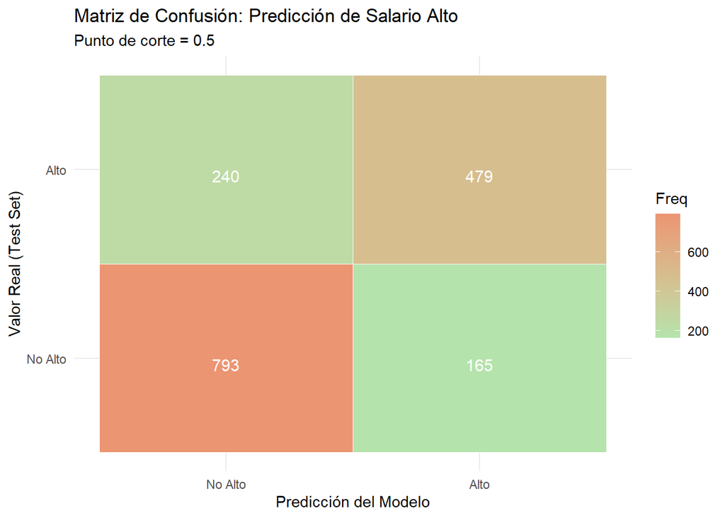

```r
# 1. Obtener probabilidades en el conjunto test
probabilidades <- predict(modelo_logistico_v2, newdata = test, type = "response")

# 2. Aplicar el punto de corte de 0.5
predicciones_clase <- ifelse(probabilidades > 0.5, "Alto", "No Alto")

# 3. Convertir a factor con los mismos niveles que la variable original
predicciones_clase <- factor(predicciones_clase, levels = c("No Alto", "Alto"))

# 4. Crear la Matriz de Confusión
matriz <- table(Real = test$SalarioAlto, Predicho = predicciones_clase)

# 5. Mejoras visuales de la matriz
# Convertir tu matriz en un data frame para ggplot
matriz_df <- as.data.frame(matriz)

ggplot(data = matriz_df, aes(x = Predicho, y = Real, fill = Freq)) +
  geom_tile(color = "white") +
  geom_text(aes(label = Freq), vjust = 1, size = 4, color = "white") +
  scale_fill_gradient(high = "#EB9573", low = "#B5E3AC") +
  labs(title = "Matriz de Confusión: Predicción de Salario Alto",
       subtitle = "Punto de corte = 0.5",
       x = "Predicción del Modelo",
       y = "Valor Real (Test Set)") +
  theme_minimal()
```

Basandonos en lo mostrado por la matriz de confusión podemos afirmar lo siguiente:

1. **Aciertos (Diagonal Principal):** El modelo identificó correctamente a 793 personas con salario “No Alto” (Verdaderos Negativos) y a 479 con salario “Alto” (Verdaderos Positivos).
2. **Errores (Fuera de la diagonal):**
- 165 Falsos Positivos: Personas que el modelo predijo con salario alto, pero no lo tienen.
- 240 Falsos Negativos: El modelo “perdió” a estas personas que realmente ganan mucho. Esto coincide con la tendencia del modelo a infravalorar los ingresos más altos vista en los gráficos de residuos.

### 2.5. Predicción

```r
# 1. Probabilidades calculadas para el test
prob_test <- predict(modelo_logistico_v2, newdata = test, type = "response")

# 2. Añadir la probabilidad al conjunto test para poder visualizarla
test_con_prob <- cbind(test, Probabilidad = prob_test)

# 3. Ordenar de mayor a menor probabilidad y seleccionar los 5 primeros
top_5_perfiles <- test_con_prob[order(-test_con_prob$Probabilidad), ]
top_5_perfiles <- head(top_5_perfiles, 5)

# 4. Seleccionar las columnas clave para la tabla
columnas_interes <- c("SEXO", "ESTU", "ANOANTI", "JAP", "CNO1_grp", "Probabilidad")
tabla_final <- top_5_perfiles[, columnas_interes]

# Mostrar tabla
print(tabla_final)
```

```
##        SEXO                   ESTU ANOANTI  JAP
## 1773 Hombre 6. Estudios Superiores      38 1592
## 9400 Hombre 6. Estudios Superiores      38 1495
## 9569 Hombre 6. Estudios Superiores      33 1633
## 1264 Hombre 6. Estudios Superiores      36 1670
## 6080 Hombre 6. Estudios Superiores      28 1840
##                               CNO1_grp Probabilidad
## 1773 1. Dirección y Alta Cualificación    0.9929509
## 9400 1. Dirección y Alta Cualificación    0.9908779
## 9569 1. Dirección y Alta Cualificación    0.9898601
## 1264            2. Cualificación Media    0.9865212
## 6080 1. Dirección y Alta Cualificación    0.9839448
```

### 2.6 Bondad del ajuste y curva ROC

```r
# Cálculo diferencia de devianzas
dif_devianza <- modelo_logistico_v2$null.deviance - modelo_logistico_v2$deviance

# Diferencia grados de libertad
dif_df <- modelo_logistico_v2$df.null - modelo_logistico_v2$df.residual

# p-valor
p_valor_global <- pchisq(dif_devianza, df = dif_df, lower.tail = FALSE)

print(p_valor_global)
```

```
## [1] 0
```

Con esto echazamos la hipótesis nula de que el modelo no aporta nada. El conjunto de variables explicativas tiene un efecto real y potente sobre la probabilidad de tener un salario alto. Por tanto se concluye que el conjunto de variables (SEXO, ESTU, ANOANTI, etc.) explica la probabilidad de tener un salario alto de forma mucho más eficaz que el simple azar o el promedio.

```r
curva_roc <- roc(test$SalarioAlto, probabilidades)
```

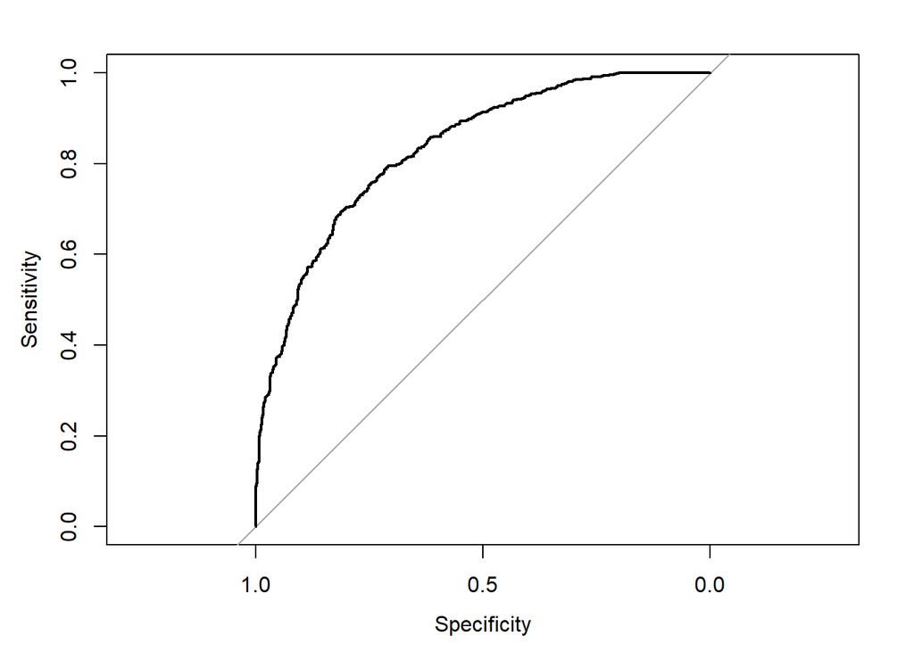

```r
# Dibujar la curva
plot(curva_roc)
```

```r
# Calcular el AUC
auc_resultado <- auc(curva_roc)
print(auc_resultado)
```

```
## Area under the curve: 0.8334
```

### 3. Resumen ejecutivo y Reflexión Ética

### 3.1. Tabla Resumen

Resumen de Resultados del Modelo Logístico

| Pregunta | Estadistico | Conclusion |
| --- | --- | --- |
| Determinantes | OR ESTU6: 22.5 | Educación es el mayor protector |
| Brecha Género | OR Mujer: 0.317 | Penalización femenina severa |
| Ocupación | OR CNO3: 0.254 | Baja cualificación es riesgo |
| Fiabilidad | Exactitud: 75.8% | Modelo robusto y significativo |
| Detección | Sensibilidad: 66.6% | Mejor prediciendo salarios bajos |

Aunque el modelo presenta una eficacia global excelente y una alta capacidad discriminatoria ($AUC$ robusto), su mayor precisión para identificar salarios bajos sugiere la existencia de variables no observadas que influyen en la movilidad hacia los niveles de renta más elevados.

### 3.2. Conclusiones y Reflexión Ética

Existen limitaciones críticas: los modelos no capturan variables como los cuidados no remunerados, la discriminación directa o las habilidades específicas. Además, usar el “sexo registrado” es una aproximación limitada del género. Éticamente, esto implica que la brecha detectada es solo la “punta del iceberg”; el modelo confirma una penalización estadística injustificada, pero los sesgos de los datos podrían estar infravalorando la magnitud real de la segregación laboral.